# Data quality of NHS Digital GP appointment records

Mark Green and Vittal Katikeriddi

```r
# Libraries
library(data.table) # For data wrangling
library(lubridate) # To deal with date information
library(ggplot2) # For visualisations
```

## Purpose

The **aim** of this report is to investigate the extent of missing data in the data NHS Digital supply for monitoring General Practice (GP) consultations across England (see [here](https://digital.nhs.uk/data-and-information/publications/statistical/appointments-in-general-practice)). This work is to supplement analyses of the dataset and help us assess the quality of the data.

All code and resources can be openly accessed [here](https://github.com/markagreen/remote_GP_consultations). The report is created using R notebooks which embed all R code, outputs and plots within this document.

The structure of the report will assess the extent of missing data on key variables we hae used in our man analysis. Each section of the report is therefore dedicated to each variable.

```r
## Get data ready for analysis ##

# Load data
files <- fs::dir_ls("./Data/CCG monthly consultations/") # Get list of all files in
l <- lapply(files, fread, sep = ",") # Load in monthly data on GP interactions (save as list)
ccg_consult_month <- rbindlist(l) # Convert to single table
rm(l, files)

# Tidy up dates (some inconsistent coding)
ccg_consult_month$Appointment_Month[ccg_consult_month$Appointment_Month == "Apr-20"] <- "APR2020"
ccg_consult_month$Appointment_Month[ccg_consult_month$Appointment_Month == "Apr-21"] <- "APR2021"
ccg_consult_month$Appointment_Month[ccg_consult_month$Appointment_Month == "Aug-20"] <- "AUG2020"
ccg_consult_month$Appointment_Month[ccg_consult_month$Appointment_Month == "Aug-21"] <- "AUG2021"
ccg_consult_month$Appointment_Month[ccg_consult_month$Appointment_Month == "Dec-20"] <- "DEC2020"
ccg_consult_month$Appointment_Month[ccg_consult_month$Appointment_Month == "Jan-21"] <- "JAN2021"
ccg_consult_month$Appointment_Month[ccg_consult_month$Appointment_Month == "Feb-21"] <- "FEB2021"
ccg_consult_month$Appointment_Month[ccg_consult_month$Appointment_Month == "Jul-20"] <- "JUL2020"
ccg_consult_month$Appointment_Month[ccg_consult_month$Appointment_Month == "Jul-21"] <- "JUL2021"
ccg_consult_month$Appointment_Month[ccg_consult_month$Appointment_Month == "Jun-20"] <- "JUN2020"
ccg_consult_month$Appointment_Month[ccg_consult_month$Appointment_Month == "Jun-21"] <- "JUN2021"
ccg_consult_month$Appointment_Month[ccg_consult_month$Appointment_Month == "Mar-20"] <- "MAR2020"
ccg_consult_month$Appointment_Month[ccg_consult_month$Appointment_Month == "Mar-21"] <- "MAR2021"
ccg_consult_month$Appointment_Month[ccg_consult_month$Appointment_Month == "May-20"] <- "MAY2020"
ccg_consult_month$Appointment_Month[ccg_consult_month$Appointment_Month == "May-21"] <- "MAY2021"
ccg_consult_month$Appointment_Month[ccg_consult_month$Appointment_Month == "Nov-20"] <- "NOV2020"
ccg_consult_month$Appointment_Month[ccg_consult_month$Appointment_Month == "Oct-20"] <- "OCT2020"
ccg_consult_month$Appointment_Month[ccg_consult_month$Appointment_Month == "Sep-20"] <- "SEP2020"
```

## Who delivered care

The data classify who gave the care; divided into three options: GP, other practice staff and unknown (i.e., missing). Let’s examine the total number of appointments over the study period.

```r
df1 <- ccg_consult_month[, list(Frequency = sum(COUNT_OF_APPOINTMENTS, na.rm=T)), by = c("HCP_TYPE")] # Aggregate by variable of interest
df1$Percent <- (df1$Frequency / sum(df1$Frequency)) * 100 # Calculate percentage
df1$Percent <- round(df1$Percent, digits = 1) # Round decimal places
df1 # Print
```

| HCP_TYPE | Frequency | Percent |
| --- | --- | --- |
| GP | 373641145 | 51.7 |
| Other Practice staff | 327432119 | 45.3 |
| Unknown | 21242870 | 2.9 |

```r
NA
```

Low missing data here with 2.9% of all appointments missing this information, which is reassuring. Next, let’s consider if this has changed over time to assess if the pandemic has led to additional bias here.

[figure not shown]

It appears that there has been a slight increase over time, increasing at the England average from 2.5% (March 2019) to 3.2% (August 2021). The extent of this increase probably suggests nothing too much to worry about. Most CCGs follow this general pattern, although there is a wide range of values (most remain below 5%). The single line that has increased considerably post-pandemic is Cornwall And The Isles Of Scilly Health And Social Care Partnership STP (peaking at 12.7% in May 2021).

## Mode of care

The next variable is how care was delivered. Options include face-to-face (at a General Practice), home visit (at a patients home), telephone, online/video call, and unknown (missing).

```r
df2 <- ccg_consult_month[, list(Frequency = sum(COUNT_OF_APPOINTMENTS, na.rm=T)), by = c("APPT_MODE")] # Aggregate by variable of interest
df2$Percent <- (df2$Frequency / sum(df2$Frequency)) * 100 # Calculate percentage
df2$Percent <- round(df2$Percent, digits = 1) # Round decimal places
df2 # Print
```

| APPT_MODE | Frequency | Percent |
| --- | --- | --- |
| Face-to-Face | 471796589 | 65.3 |
| Home Visit | 5392833 | 0.7 |
| Telephone | 209950409 | 29.1 |
| Video/Online | 3543697 | 0.5 |
| Unknown | 31632606 | 4.4 |

```r
NA
```

4.4% of appointments over the whole study period were missing information over mode of care. Let’s visualise how this changed over time.

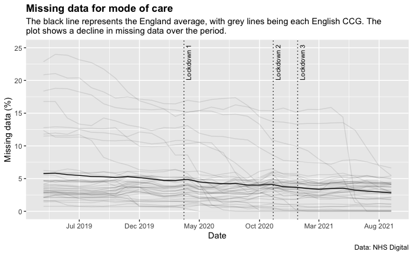

At the national level, there has been a consistent decline in missing data over the study period (falling from 5.8% in March 2019 to 2.8% in August 2021). The decreasing trend appears to be mostly driven by large improvements in a small number of CCGs with very high missing data at the start of the period, with most other CCGs having flat lines over the period.

## Time to appointment

We next consider the time from an individual booking their appointment to being seen. Responses are divided into categories reflecting the time inbetween booking and appointment. We treat ‘unknown or data issue’ as missing data here.

```r
df4 <- ccg_consult_month[, list(Frequency = sum(COUNT_OF_APPOINTMENTS, na.rm=T)), by = c("TIME_BETWEEN_BOOK_AND_APPT")] # Aggregate by variable of interest
df4$Percent <- (df4$Frequency / sum(df4$Frequency)) * 100 # Calculate percentage
df4$Percent <- round(df4$Percent, digits = 2) # Round decimal places
df4 # Print
```

| TIME_BETWEEN_BOOK_AND_APPT | Frequency | Percent |
| --- | --- | --- |
| 1 Day | 60852853 | 8.42 |
| 15 to 21 Days | 44279735 | 6.13 |
| 2 to 7 Days | 146801500 | 20.32 |
| 22 to 28 Days | 28519959 | 3.95 |
| 8 to 14 Days | 87412604 | 12.10 |
| More than 28 Days | 26691887 | 3.70 |
| Same Day | 327450154 | 45.33 |
| Unknown / Data Issue | 307442 | 0.04 |

```r
NA
```

Overall, there is very little missing data here for this variable (0.04% of all appointments). This probably reflects that the data are generated automatically by the system, rather than needing manual input. While this would suggest that the variable is good, we will still explore if there is any temporal pattern.

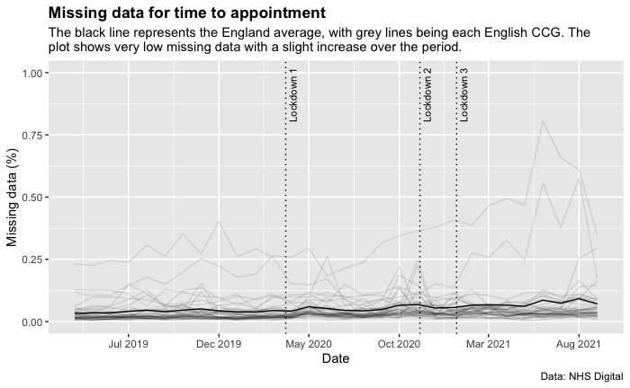

The national trend line does have a small increase in the pandemic period, however the values are all very low that this is ok. Similarly, the values for CCGs are all very low, with the highest ones all less than 1%. The line representing the two high lines are both in London - East London Health and Care Partnership (max value 0.8% in May 2021) and Our Healthier South East London (0.6% in July 2021).

## Attended appointment

The final variable we consider is whether an individual attended their appointment. The measure contains three options: attended, did not attend (DNA), and unknown (missing).

```r
df5 <- ccg_consult_month[, list(Frequency = sum(COUNT_OF_APPOINTMENTS, na.rm=T)), by = c("APPT_STATUS")] # Aggregate by variable of interest
df5$Percent <- (df5$Frequency / sum(df5$Frequency)) * 100 # Calculate percentage
df5$Percent <- round(df5$Percent, digits = 1) # Round decimal places
df5 # Print
```

| APPT_STATUS | Frequency | Percent |
| --- | --- | --- |
| Attended | 654841994 | 90.7 |
| DNA | 31341272 | 4.3 |
| Unknown | 36132868 | 5.0 |

```r
NA
```

The majority of appointments were attended (90.7%), with 5% having missing data. Let’s consider if this value changes over time.

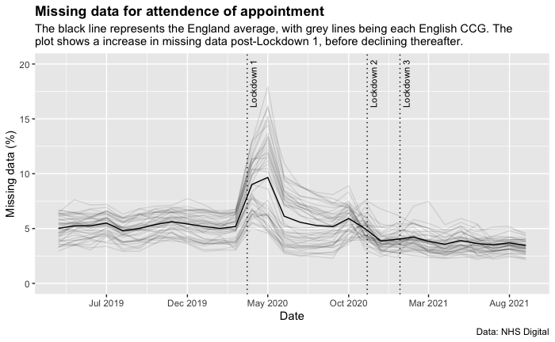

The trend line is fairly stable/flat pre-pandemic, before there is a sharp rise and almost doubling in missing data; rising from 5.2% in February 2020 to 9%/9.7% in March/April 2020 respectively). For these few months, there is large heterogeneity in experiences for CCGs with some increasing to very high amounts of missing data (e.g., Bath and North East Somerset, Swindon and Wiltshire has 18% missing in April 2020). Following this initial rise, there is improvement in the data quality with declining missing data. Indeed the level of missingness has declined from 5% in March 2019, to 3.5% in August 2021.